# Modeling Florida octocoral trends: Density data

Ronen Liberman

6-17-2024

*In this markdown file I am going to work with data that was prepared in a previous script. I am going to clean the data a little bit, then using model selection test for the most significant parameters that influence state of octocoral population in the last 11 years*

#Data prep. for modelling Here I filter the data so I can model density of Total population across years 2013 - 2023. The data was prepared in: “Creating_binding_all_datasets.R”

```r
dat <- read.csv("~/Postdocing_NSU/Octocoral forests/Manuscript/all_density_and_heights_by_stationID.csv")
head(dat)
```

```
##   Year   Date.x Subregion Habitat SiteID Site_name StationID SPP_Code
## 1 2012 6/1/2012        DT       P     27  The Maze       271     GVEN
## 2 2012 6/1/2012        DT       P     27  The Maze       271     AAME
## 3 2012 6/1/2012        DT       P     27  The Maze       271     EFLE
## 4 2012 6/1/2012        DT       P     27  The Maze       271     ABIP
## 5 2012 6/1/2012        DT       P     27  The Maze       271     PPOR
## 6 2012 6/1/2012        DT       P     27  The Maze       271     TOCT
##                   sciName density mean_height        sd biomass  n
## 1      Gorgonia_ventalina     1.6    25.18750 14.492383     403 16
## 2 Antillogorgia_americana     1.7    37.41176 23.315925     636 17
## 3        Eunicea_flexuosa     1.4    10.28571  8.342925     144 14
## 4 Antillogorgia_bipinnata     2.2    18.22727 13.023538     401 22
## 5   Pseudoplexaura_porosa     0.3          NA        NA      NA NA
## 6        Total_Octocorals     7.5          NA        NA      NA NA
##   ProjectRegion Site.Code Depth  latDD    lonDD latDeg latMin lonDeg lonMin
## 1         NPSDT       1PA    42 24.609 -82.9496     24  36.54    -82 56.976
## 2         NPSDT       1PA    42 24.609 -82.9496     24  36.54    -82 56.976
## 3         NPSDT       1PA    42 24.609 -82.9496     24  36.54    -82 56.976
## 4         NPSDT       1PA    42 24.609 -82.9496     24  36.54    -82 56.976
## 5         NPSDT       1PA    42 24.609 -82.9496     24  36.54    -82 56.976
## 6         NPSDT       1PA    42 24.609 -82.9496     24  36.54    -82 56.976
```

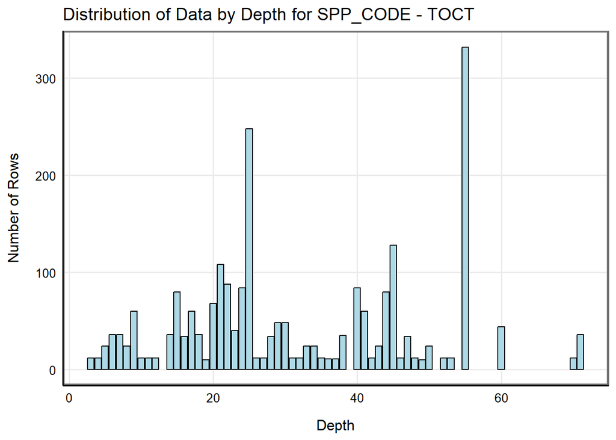

```r
# Here i test what should be the rangesof the data depth-groups based on number of rows
# Filter the data for SPP_CODE == "TOCT"
TOCT_data <- dat %>%
  filter(SPP_Code == "TOCT")

# Convert Depth to numeric (if not already done)
TOCT_data$Depth <- as.numeric(as.character(TOCT_data$Depth))

# Plot the distribution of data by Depth
ggplot(TOCT_data, aes(x = Depth)) +
  geom_bar(fill = "lightblue", color = "black") +
  labs(title = "Distribution of Data by Depth for SPP_CODE - TOCT", x = "Depth", y = "Number of Rows")
```

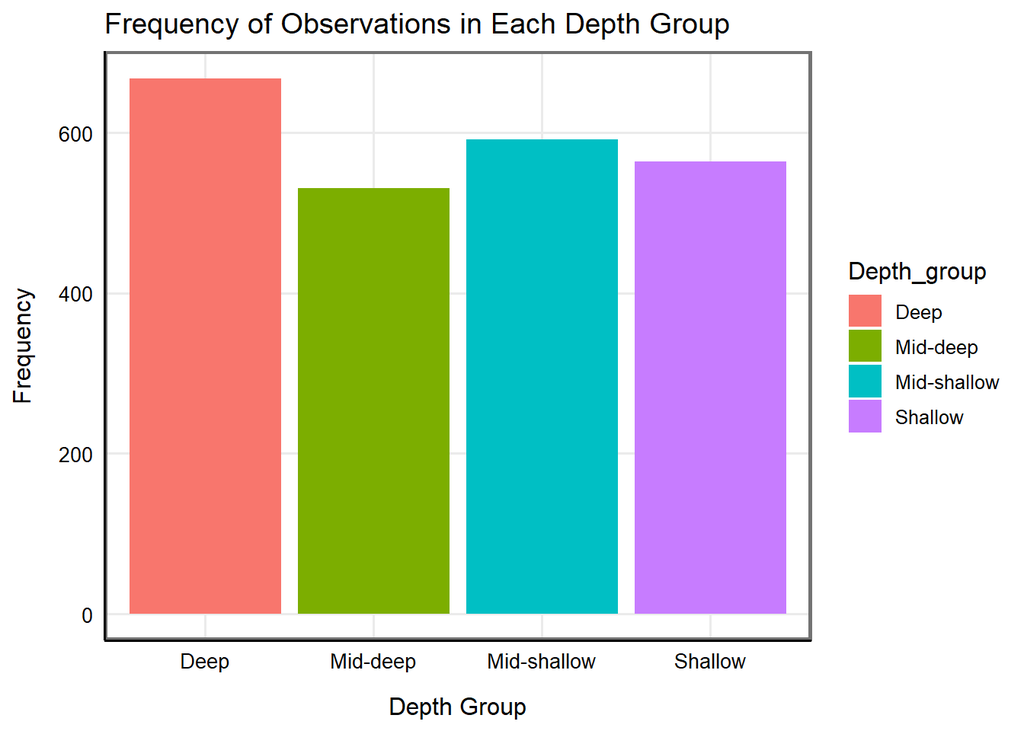

```r
# Calculate quartiles for the Depth variable
quartiles <- TOCT_data %>%
  summarise(Q1 = quantile(Depth, 0.25),
            Median = quantile(Depth, 0.5),
            Q3 = quantile(Depth, 0.75))

# Create a frequency table of rows per depth
depth_frequency <- TOCT_data %>%
  group_by(Depth_group = cut(Depth, breaks = c(-Inf, quartiles$Q1, quartiles$Median, quartiles$Q3, Inf))) %>%
  summarise(Frequency = n())

# Rename the Depth_group variable for clarity
depth_frequency$Depth_group <- gsub("\\(|\\]", "", as.character(depth_frequency$Depth_group))

# Assign data groups according to the frequncy found above.
dat_4groups <- dat %>%
  mutate(Depth_group = case_when(
    Depth < 21 ~ "Shallow",
    Depth >= 21 & Depth < 28 ~ "Mid-shallow", Depth >= 28 & Depth < 45  ~ "Mid-deep",
    Depth >= 45 ~ "Deep"
  ))

#visualize
dat_4groups %>% filter(SPP_Code == "TOCT") %>%  ggplot(aes(x = Depth_group, fill = Depth_group)) +
  geom_bar() +
  labs(title = "Frequency of Observations in Each Depth Group", x = "Depth Group", y = "Frequency")
```

```r
# ok , this makes some sense.

#Generate the dataset
Total.octo <- dat_4groups %>% filter(SPP_Code == "TOCT")
# check the number of unique ProjectRegion
Total.octo %>%
  distinct(ProjectRegion )
```

```
##   ProjectRegion
## 1         NPSDT
## 2   NPSDT/FKNMS
## 3         FKNMS
## 4       SECREMP
```

```r
# make NPSDT the only DT ProjectRegion
Total.octo <- Total.octo %>%
  mutate(ProjectRegion = ifelse(ProjectRegion == "NPSDT/FKNMS", "NPSDT", ProjectRegion))

Total.octo %>%
  distinct(Habitat )
```

```
##     Habitat
## 1         P
## 2        OD
## 3     Inner
## 4 Nearshore
## 5     Outer
## 6    Middle
## 7        OS
```

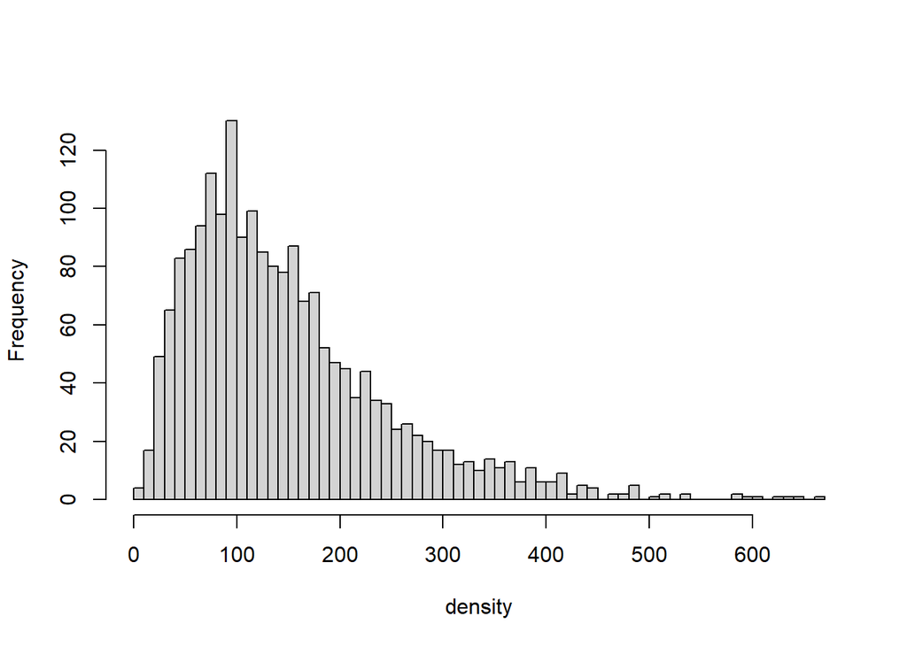

```r
#Here I explore a bit the outlliars in my data, some zero's, some low counts in specific sites
#test for zero density values
#Looking at density
Total.zero <- Total.octo %>% filter(density == "0")

# Creating a list of sites that should be omitted from the datasets
omit_sites <- c("Martin County 1" ,"Martin County 2","Davis Rock","Palm Beach 1","Red Dun Reef","Palmata Patch","Loggerhead Patch", "Texas Rock","Broward County A")

#omit_sites2 <- c("Red Dun Reef","Palmata Patch","Loggerhead Patch", "Texas Rock","Broward County A")

Total.octo_no_2012 <- dat_4groups %>% filter(SPP_Code == "TOCT") %>%
mutate(ProjectRegion = ifelse(ProjectRegion == "NPSDT/FKNMS", "NPSDT", ProjectRegion)) %>% # Count the number of unique ProjectRegion
 filter(!(Site_name %in% omit_sites)) %>%
  filter(Year!= "2012") %>%
  mutate(SiteID = as.factor(SiteID),
         StationID = as.factor(StationID),
         Year =  as.factor(Year),
         counts = (10*density)
  )

#view(Total.octo_no_2012)
#Total.octo %>%
 # distinct(ProjectRegion )

#Total.octo %>%
 # distinct(Habitat )

# look at the frequency of counts

hist(Total.octo_no_2012$counts, breaks=50, xlab = "density", main = NULL, freq = TRUE)
```

```r
#round density for avoiding non-integer issues with poisson or nbinom.
Total.octo_no_2012$offset <- 10
```

Using different models I can examine the most significant factors affecting Total octocoral abundance. I am using count data and different explenatory varables. I am using a model selection method using the AIC parameter to select for the best model. Afterwards I am running a model validation functions on the best model.

Modeling using NBINOM2 dist.

```r
nbinom_glmm_full_model_2013 = glmmTMB(counts ~ Year * Subregion +Depth+Habitat+(1|SiteID/StationID),
                          family = nbinom2,
                          data = Total.octo_no_2012)
```

```
## dropping columns from rank-deficient conditional model: HabitatP
```

```r
#nbinom_glmm_full_model <- update(nbinom_glmm_full_model, control = glmmTMBControl(optCtrl=list(iter.max=1e3,eval.max=1e3)))

nbinom_glmm_model_depthgroup_interaction_2013 <- glmmTMB(counts ~ Year * Depth+ (1|SiteID/StationID),
                      family = nbinom2,
                      data = Total.octo_no_2012)
#nbinom_glmm_model_depthgroup_interaction <- #update(nbinom_glmm_model_depthgroup_interaction, control = glmmTMBControl(optCtrl=list(iter.max=1e3,eval.max=1e3)))

nbinom_glmm_model_depthgroup_2013 <- glmmTMB(counts ~ Year * Depth_group + (1|SiteID/StationID),
                                 family = nbinom2,
                                 data = Total.octo_no_2012)
#nbinom_glmm_model_depthgroup <- update(nbinom_glmm_model_depthgroup, control = glmmTMBControl(optCtrl=list(iter.max=1e3,eval.max=1e3)))

nbinom_glmm_model_depth_2013 <- glmmTMB(counts ~ Year + Depth + (1|SiteID/StationID),
                                 family = nbinom2,
                                 data = Total.octo_no_2012)

nbinom_glmm_model_Subregion_2013 <- glmmTMB(density ~ Year * Subregion+(1|SiteID/StationID),
                               family = nbinom2,
                                data = Total.octo_no_2012)
#nbinom_glmm_model_Subregion <- update(nbinom_glmm_model_Subregion, control = glmmTMBControl(optCtrl=list(iter.max=1e3,eval.max=1e3)))

nbinom_glmm_model_Subregion2_2013 <- glmmTMB(counts ~ Year + Subregion+(1|SiteID/StationID),
                                 family = nbinom2,
                                 data = Total.octo_no_2012)
  #  nbinom_glmm_model_Subregion2 <- update(nbinom_glmm_model_Subregion2, control = glmmTMBControl(optCtrl=list(iter.max=1e3,eval.max=1e3)))

nbinom_glmm_model_Subregion3_2013 <- glmmTMB(counts ~ Year * Subregion+Depth + (1|SiteID/StationID),
                                 family = nbinom2,
                                 data = Total.octo_no_2012)
#nbinom_glmm_model_Subregion3 <- update(nbinom_glmm_model_Subregion3, control = glmmTMBControl(optCtrl=list(iter.max=1e3,eval.max=1e3)))


nbionom_glmm_model_ProjectRegion_2013 <- glmmTMB(counts ~ Year * ProjectRegion+(1|SiteID/StationID),
                                 family = nbinom2,
                                 data = Total.octo_no_2012)
#nbionom_glmm_model_ProjectRegion <- update(nbionom_glmm_model_ProjectRegion, control = glmmTMBControl(optCtrl=list(iter.max=1e3,eval.max=1e3)))

nbinom_glmm_model_ProjectRegion2_2013 <- glmmTMB(counts ~ Year + ProjectRegion+(1|SiteID/StationID),
                                 family = nbinom2,
                                 data = Total.octo_no_2012)
#nbinom_glmm_model_ProjectRegion2 <- update(nbinom_glmm_model_ProjectRegion2, control = glmmTMBControl(optCtrl=list(iter.max=1e3,eval.max=1e3)))

nbinom_glmm_model_ProjectRegion3_2013 <- glmmTMB(counts ~ Year * ProjectRegion+Depth+(1|SiteID/StationID),
                                 family = nbinom2,
                                 data = Total.octo_no_2012)

nbinom_glmm_model_ProjectRegion4_2013 <- glmmTMB(counts ~ Year * ProjectRegion+Habitat+(1|SiteID/StationID),
                                 family = nbinom2,
                                 data = Total.octo_no_2012)
```

```
## dropping columns from rank-deficient conditional model: HabitatP
```

```r
nbinom_glmm_model_Year_2013 <- glmmTMB(counts ~ as.numeric(Year) + (1|SiteID/StationID),
                                 family = nbinom2,
                                 data = Total.octo_no_2012)
#nbinom_glmm_model_Year <- update(nbinom_glmm_model_Year, control = glmmTMBControl(optCtrl=list(iter.max=1e3,eval.max=1e3)))


nbinom_glmm_model_habitat_2013 <- glmmTMB(counts ~ Year * Habitat+(1|SiteID/StationID),
                                 family = nbinom2,
                                 data = Total.octo_no_2012)


nbinom_glmm_model_habitat2_2013 <- glmmTMB(counts ~ Year + Habitat+(1|SiteID/StationID),
                                 family = nbinom2,
                                 data = Total.octo_no_2012)

nbinom_glmm_model_habitat3_2013 <- glmmTMB(counts ~ Year + Habitat+Subregion+(1|SiteID/StationID),
                                 family = nbinom2,
                                 data = Total.octo_no_2012)
```

```
## dropping columns from rank-deficient conditional model: SubregionUK
```

```r
nbinom_glmm_model_null_2013 <- glmmTMB(counts ~  + 1,
                           family = nbinom2,
                            data = Total.octo_no_2012)
```

```r
AICtab(nbinom_glmm_full_model_2013,
       nbinom_glmm_model_depthgroup_interaction_2013,nbinom_glmm_model_depthgroup_2013,
       nbinom_glmm_model_depth_2013,
    nbinom_glmm_model_Subregion_2013,nbinom_glmm_model_Subregion2_2013, nbinom_glmm_model_Subregion3_2013,
    nbionom_glmm_model_ProjectRegion_2013,nbinom_glmm_model_ProjectRegion2_2013,
    nbinom_glmm_model_ProjectRegion3_2013,nbinom_glmm_model_ProjectRegion4_2013,
    nbinom_glmm_model_Year_2013,
    nbinom_glmm_model_habitat_2013,nbinom_glmm_model_habitat2_2013,nbinom_glmm_model_habitat3_2013,
    nbinom_glmm_model_null_2013)
```

```
##                                               dAIC    df
## nbinom_glmm_model_Subregion_2013                  0.0 80
## nbinom_glmm_model_habitat_2013                 8688.9 80
## nbinom_glmm_model_Subregion3_2013              8720.0 81
## nbinom_glmm_full_model_2013                    8725.3 86
## nbionom_glmm_model_ProjectRegion_2013          8792.9 36
## nbinom_glmm_model_ProjectRegion3_2013          8792.9 37
## nbinom_glmm_model_ProjectRegion4_2013          8794.8 41
## nbinom_glmm_model_depthgroup_interaction_2013  8852.7 25
## nbinom_glmm_model_Subregion2_2013              8853.0 20
## nbinom_glmm_model_ProjectRegion2_2013          8855.8 16
## nbinom_glmm_model_depth_2013                   8856.3 15
## nbinom_glmm_model_habitat3_2013                8856.4 25
## nbinom_glmm_model_habitat2_2013                8858.0 20
## nbinom_glmm_model_depthgroup_2013              8869.5 47
## nbinom_glmm_model_Year_2013                    8992.3 5
## nbinom_glmm_model_null_2013                   12040.4 2
```

[output not shown]

[output cut: 43 more lines]

```
## Year2021:SubregionPBC  0.212600   0.117519   1.809 0.070441 .
## Year2022:SubregionPBC  0.101273   0.121410   0.834 0.404201
## Year2023:SubregionPBC  0.294023   0.121956   2.411 0.015913 *
## Year2014:SubregionUK   0.021253   0.120334   0.177 0.859812
## Year2015:SubregionUK   0.084312   0.119331   0.707 0.479853
## Year2016:SubregionUK   0.012160   0.118228   0.103 0.918083
## Year2017:SubregionUK  -0.041232   0.116221  -0.355 0.722758
## Year2018:SubregionUK   0.075716   0.119193   0.635 0.525273
## Year2019:SubregionUK   0.038048   0.116057   0.328 0.743036
## Year2020:SubregionUK   0.073846   0.112982   0.654 0.513367
## Year2021:SubregionUK   0.217810   0.114769   1.898 0.057721 .
## Year2022:SubregionUK   0.366542   0.115892   3.163 0.001563 **
## Year2023:SubregionUK   0.241069   0.119282   2.021 0.043279 *
## ---
## Signif. codes:  0 '***' 0.001 '**' 0.01 '*' 0.05 '.' 0.1 ' ' 1
```

Model validation

**Visualizing residuals** Plotting residuals vs. fitted shows more or less the same result.

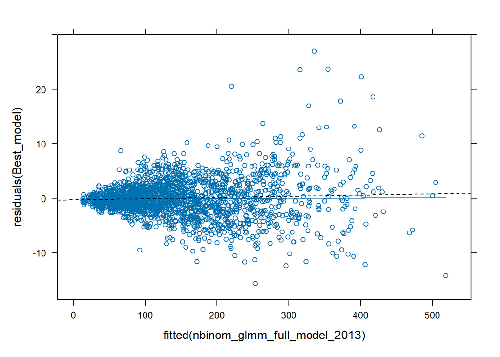

```r
# Check for residual pattern within groups and difference between groups
xyplot(residuals(Best_model) ~ fitted(nbinom_glmm_full_model_2013),
       panel=function(x, y){
         panel.xyplot(x, y)
         panel.loess(x, y, span = 3)
         panel.lmline(x, y, lty = 2)  # Least squares broken line
       }
)
```

There is some high variation in the residuals - this probably creating the outliars and dispersion roblems inmymodels. lets try to reduce the outliars by removing some marginals locations.

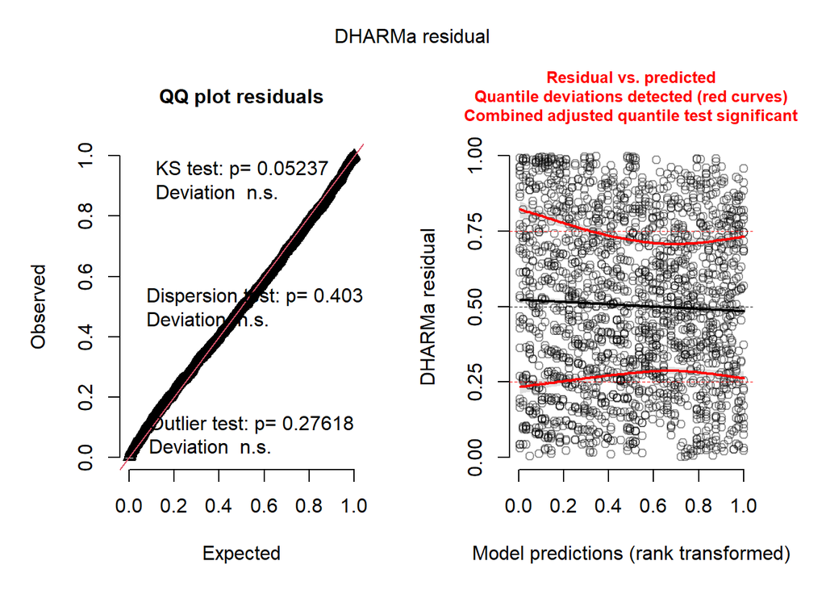

```r
simulationOutput <- simulateResiduals(Best_model, n = 2000, plot = TRUE,quantreg = T)
```

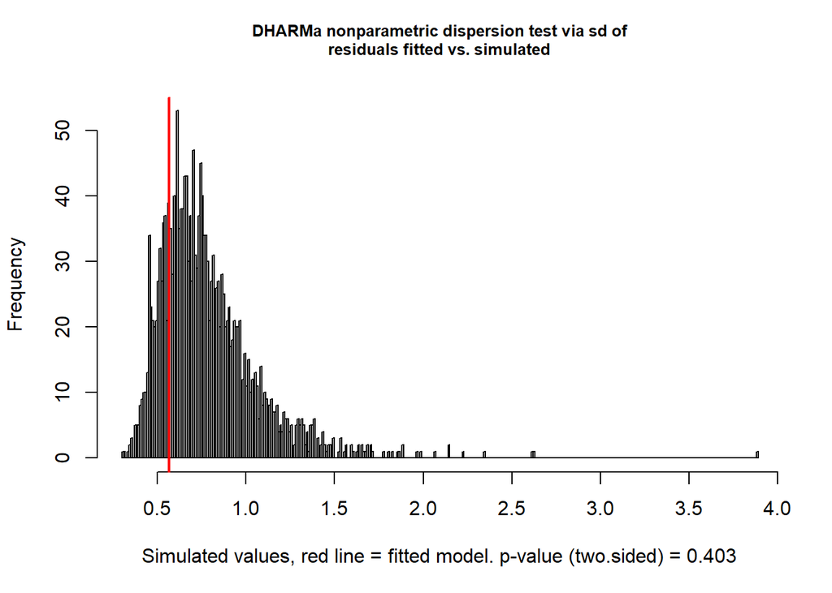

```
##
##  DHARMa nonparametric dispersion test via sd of residuals fitted vs.
##  simulated
##
## data:  simulationOutput
## dispersion = 0.72589, p-value = 0.403
## alternative hypothesis: two.sided
```

```r
testDispersion(simulationOutput) #dispersion fine
```

Validation per group - I examine individual groups in the dataset. #recalculating residuals , as I might have too many samples for Dharma to calculate, grouping by site, Year, or Subregion

#Site - this parameter has enough data point and therefore can be a good one to look into. All parameters are non significant

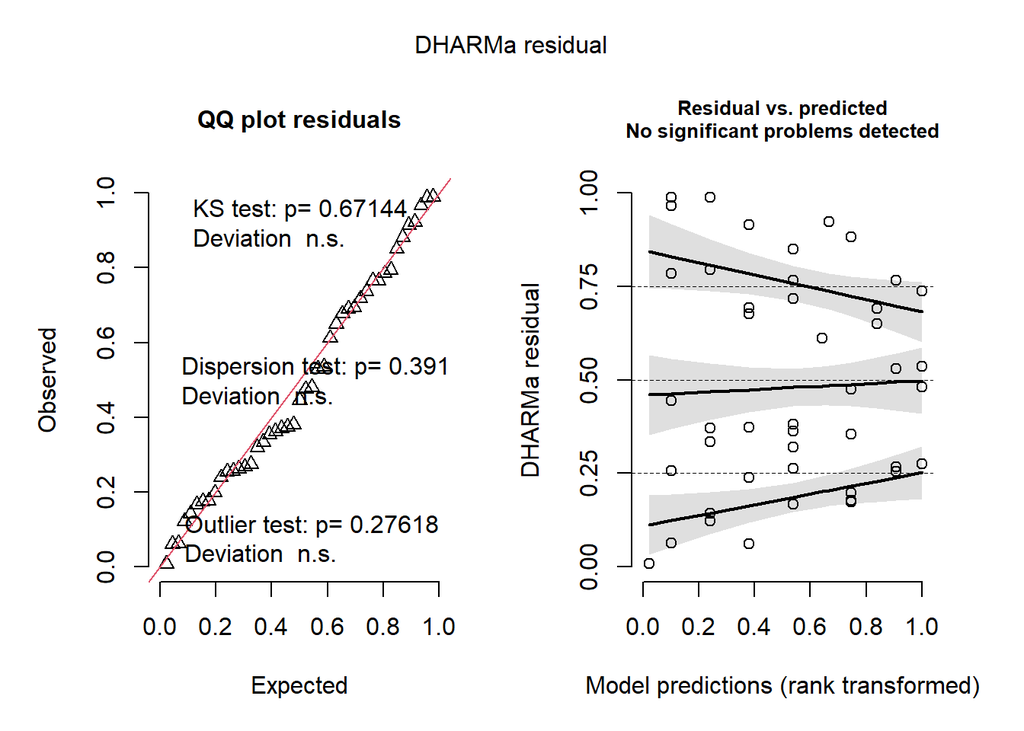

```r
resids.site <- recalculateResiduals(simulationOutput, group = Total.octo_no_2012$SiteID)
plot(resids.site) # suggest dispersion problem in the model
```

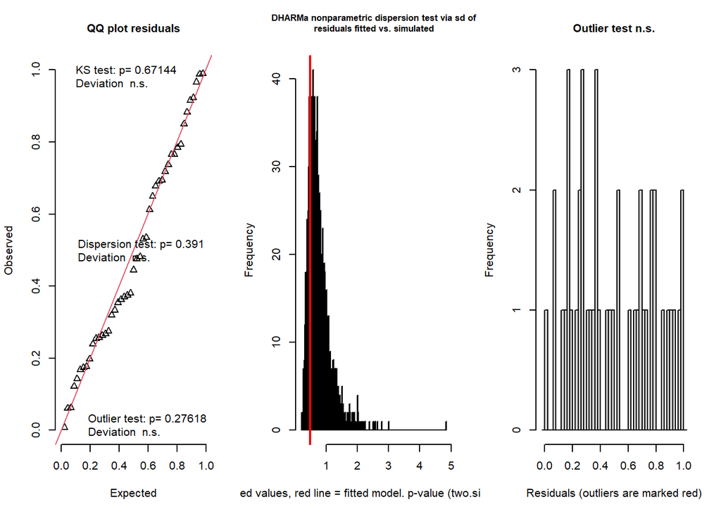

```
## $uniformity
##
##  Asymptotic one-sample Kolmogorov-Smirnov test
##
## data:  simulationOutput$scaledResiduals
## D = 0.10789, p-value = 0.6714
## alternative hypothesis: two-sided
##
##
## $dispersion
##
##  DHARMa nonparametric dispersion test via sd of residuals fitted vs.
##  simulated
##
## data:  simulationOutput
## dispersion = 0.64396, p-value = 0.391
## alternative hypothesis: two.sided
##
##
## $outliers
##
##  DHARMa outlier test based on exact binomial test with approximate
##  expectations
##
## data:  simulationOutput
## outliers at both margin(s) = 0, observations = 1956, p-value = 0.2762
## alternative hypothesis: true probability of success is not equal to 0.0009995002
## 95 percent confidence interval:
##  0.000000000 0.001884153
## sample estimates:
## frequency of outliers (expected: 0.000999500249875062 )
##                                                       0
```

```
## $uniformity
##
##  Asymptotic one-sample Kolmogorov-Smirnov test
##
## data:  simulationOutput$scaledResiduals
## D = 0.10789, p-value = 0.6714
## alternative hypothesis: two-sided
##
##
## $dispersion
##
##  DHARMa nonparametric dispersion test via sd of residuals fitted vs.
##  simulated
##
## data:  simulationOutput
## dispersion = 0.64396, p-value = 0.391
## alternative hypothesis: two.sided
##
##
## $outliers
##
##  DHARMa outlier test based on exact binomial test with approximate
##  expectations
##
## data:  simulationOutput
## outliers at both margin(s) = 0, observations = 1956, p-value = 0.2762
## alternative hypothesis: true probability of success is not equal to 0.0009995002
## 95 percent confidence interval:
##  0.000000000 0.001884153
## sample estimates:
## frequency of outliers (expected: 0.000999500249875062 )
##                                                       0
```

```r
testResiduals(resids.site) #residuals uniform, dispersion significant and problematic, no outliers b
```

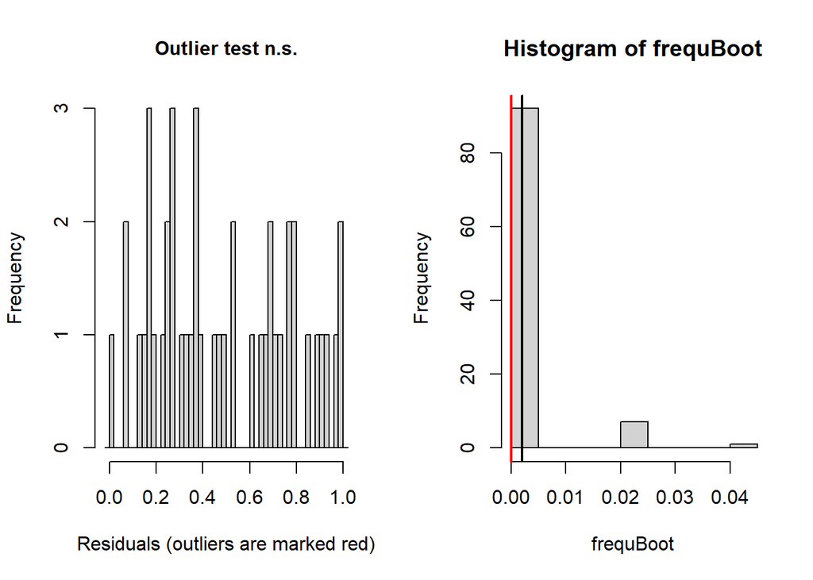

```
##
##  DHARMa bootstrapped outlier test
##
## data:  resids.site
## outliers at both margin(s) = 0, observations = 1956, p-value = 1
## alternative hypothesis: two.sided
##  percent confidence interval:
##  0.00000000 0.02222222
## sample estimates:
## outlier frequency (expected: 0.002 )
##                                    0
```

```r
testOutliers(resids.site, type = "bootstrap") #sign , outliars
```

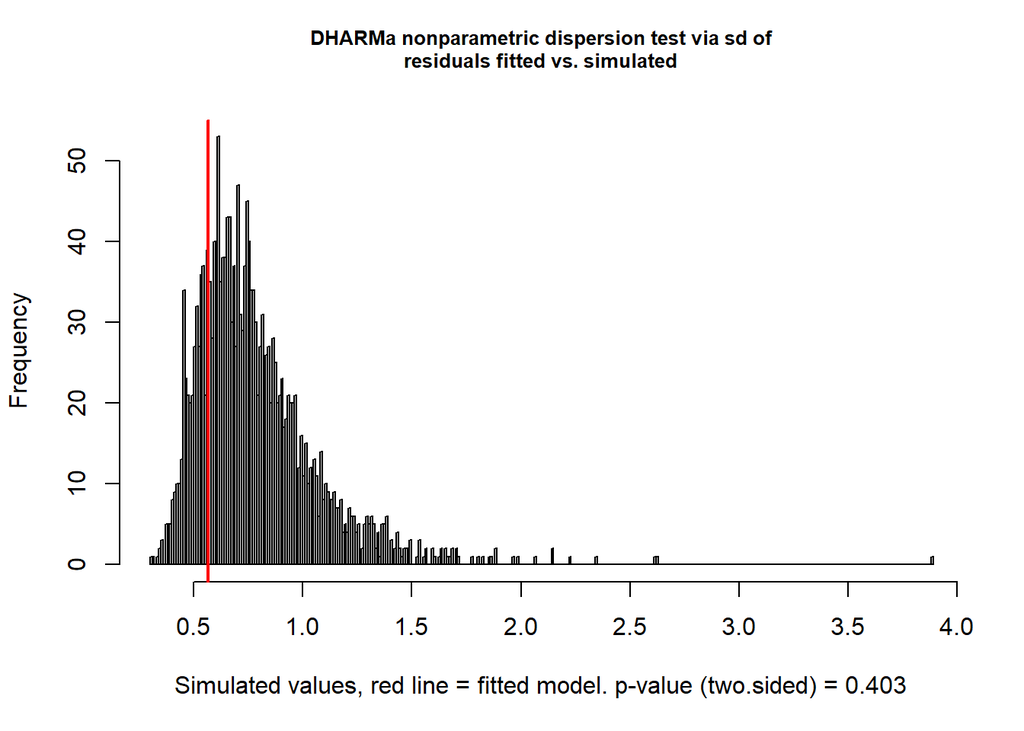

```
##
##  DHARMa nonparametric dispersion test via sd of residuals fitted vs.
##  simulated
##
## data:  simulationOutput
## dispersion = 0.72589, p-value = 0.403
## alternative hypothesis: two.sided
```

```r
testDispersion(simulationOutput) #dispersion fine
```

##Year - This factor shows significant in uniformity, however this is probably becaus ethere is only 11 years in the dataset, however, dispersion and outliars are OK.

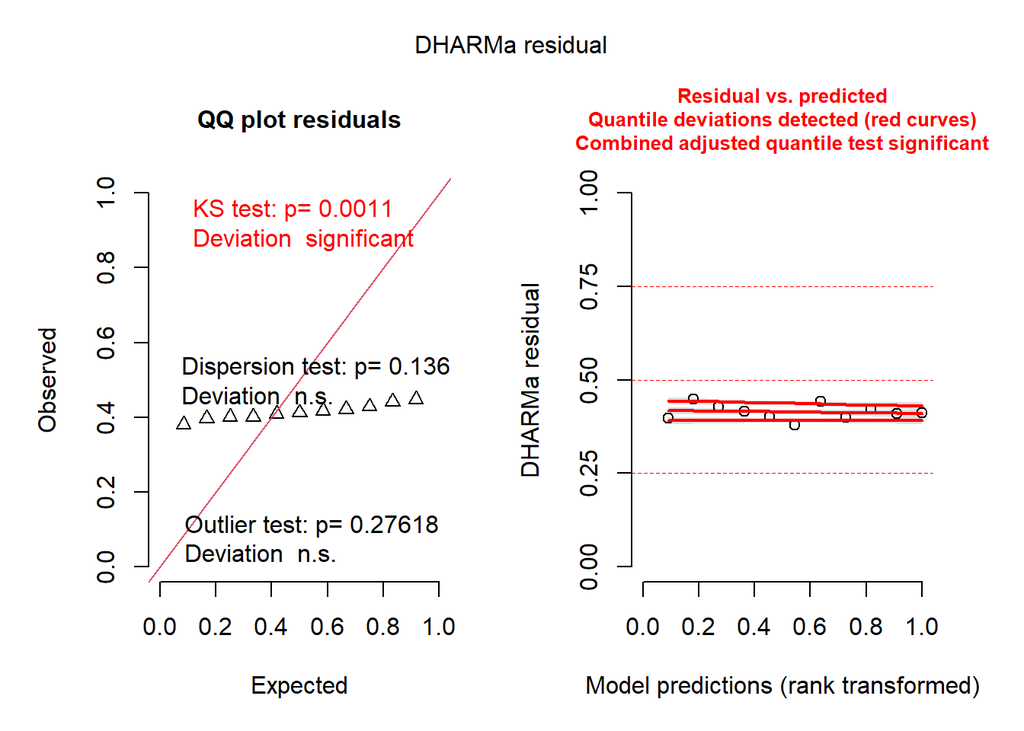

```r
resids.year<- recalculateResiduals(simulationOutput, group = Total.octo_no_2012$Year)
plot(resids.year) # suggest dispersion problem in the model
```

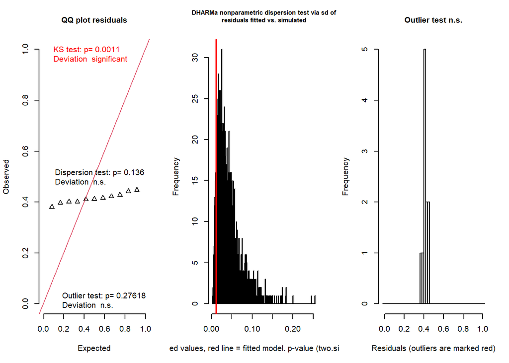

```
## $uniformity
##
##  Exact one-sample Kolmogorov-Smirnov test
##
## data:  simulationOutput$scaledResiduals
## D = 0.5525, p-value = 0.001103
## alternative hypothesis: two-sided
##
##
## $dispersion
##
##  DHARMa nonparametric dispersion test via sd of residuals fitted vs.
##  simulated
##
## data:  simulationOutput
## dispersion = 0.28726, p-value = 0.136
## alternative hypothesis: two.sided
##
##
## $outliers
##
##  DHARMa outlier test based on exact binomial test with approximate
##  expectations
##
## data:  simulationOutput
## outliers at both margin(s) = 0, observations = 1956, p-value = 0.2762
## alternative hypothesis: true probability of success is not equal to 0.0009995002
## 95 percent confidence interval:
##  0.000000000 0.001884153
## sample estimates:
## frequency of outliers (expected: 0.000999500249875062 )
##                                                       0
```

```
## $uniformity
##
##  Exact one-sample Kolmogorov-Smirnov test
##
## data:  simulationOutput$scaledResiduals
## D = 0.5525, p-value = 0.001103
## alternative hypothesis: two-sided
##
##
## $dispersion
##
##  DHARMa nonparametric dispersion test via sd of residuals fitted vs.
##  simulated
##
## data:  simulationOutput
## dispersion = 0.28726, p-value = 0.136
## alternative hypothesis: two.sided
##
##
## $outliers
##
##  DHARMa outlier test based on exact binomial test with approximate
##  expectations
##
## data:  simulationOutput
## outliers at both margin(s) = 0, observations = 1956, p-value = 0.2762
## alternative hypothesis: true probability of success is not equal to 0.0009995002
## 95 percent confidence interval:
##  0.000000000 0.001884153
## sample estimates:
## frequency of outliers (expected: 0.000999500249875062 )
##                                                       0
```

```r
testResiduals(resids.year) #residuals uniform, dispersion significant and problematic, no outliers b
```

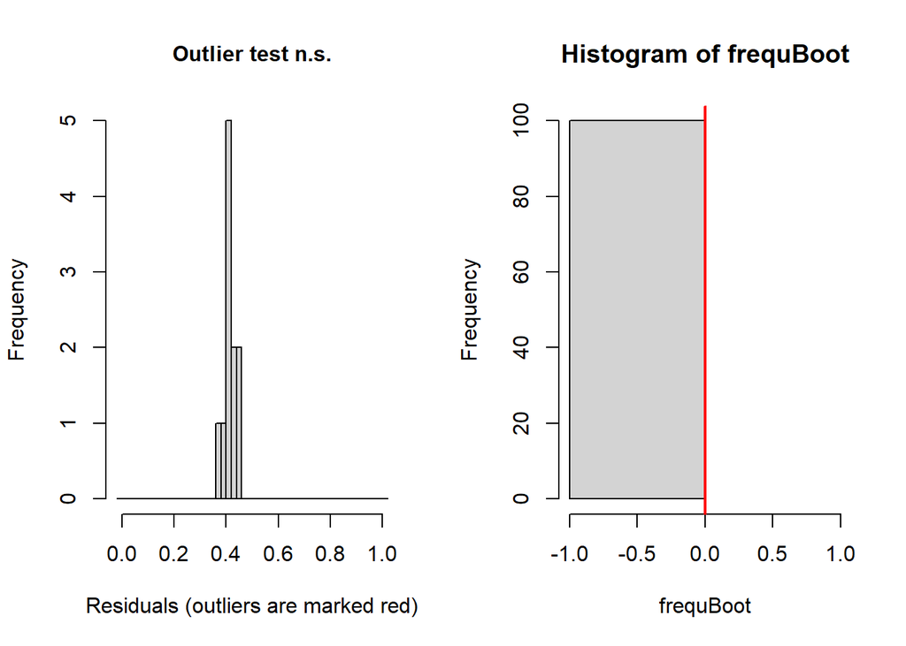

```
##
##  DHARMa bootstrapped outlier test
##
## data:  resids.year
## outliers at both margin(s) = 0, observations = 1956, p-value = 1
## alternative hypothesis: two.sided
##  percent confidence interval:
##  0 0
## sample estimates:
## outlier frequency (expected: 0 )
##                                0
```

```r
testOutliers(resids.year, type = "bootstrap") #we dont have outliars
```

Validation per group - Subregion Rest of the subgrouos were already shown above

###Subregion - this parameter is significant for dispersion, this is probably due to lack of subregions in the dataset, only 7, however, we dont find outliars and the data is pretty uniform.

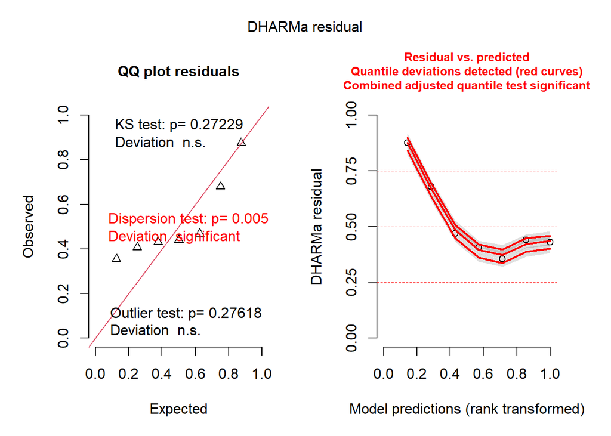

```r
resids.sub <- recalculateResiduals(simulationOutput, group = Total.octo_no_2012$Subregion)
plot(resids.sub) # suggest dispersion problem in the model
```

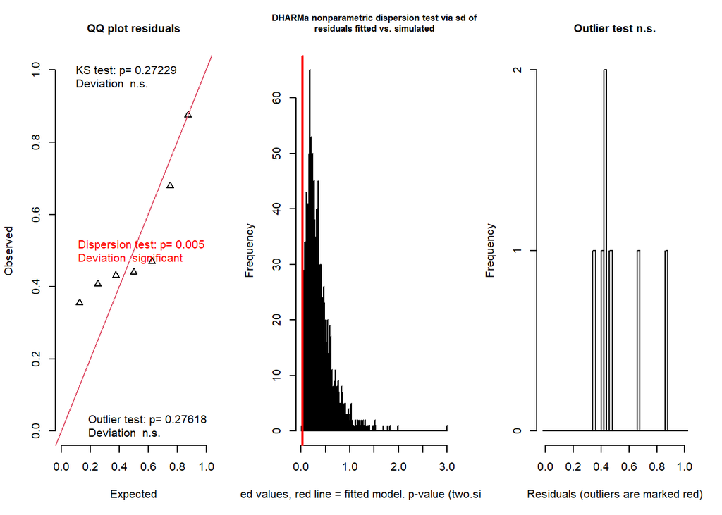

```
## $uniformity
##
##  Exact one-sample Kolmogorov-Smirnov test
##
## data:  simulationOutput$scaledResiduals
## D = 0.3545, p-value = 0.2723
## alternative hypothesis: two-sided
##
##
## $dispersion
##
##  DHARMa nonparametric dispersion test via sd of residuals fitted vs.
##  simulated
##
## data:  simulationOutput
## dispersion = 0.077918, p-value = 0.005
## alternative hypothesis: two.sided
##
##
## $outliers
##
##  DHARMa outlier test based on exact binomial test with approximate
##  expectations
##
## data:  simulationOutput
## outliers at both margin(s) = 0, observations = 1956, p-value = 0.2762
## alternative hypothesis: true probability of success is not equal to 0.0009995002
## 95 percent confidence interval:
##  0.000000000 0.001884153
## sample estimates:
## frequency of outliers (expected: 0.000999500249875062 )
##                                                       0
```

```
## $uniformity
##
##  Exact one-sample Kolmogorov-Smirnov test
##
## data:  simulationOutput$scaledResiduals
## D = 0.3545, p-value = 0.2723
## alternative hypothesis: two-sided
##
##
## $dispersion
##
##  DHARMa nonparametric dispersion test via sd of residuals fitted vs.
##  simulated
##
## data:  simulationOutput
## dispersion = 0.077918, p-value = 0.005
## alternative hypothesis: two.sided
##
##
## $outliers
##
##  DHARMa outlier test based on exact binomial test with approximate
##  expectations
##
## data:  simulationOutput
## outliers at both margin(s) = 0, observations = 1956, p-value = 0.2762
## alternative hypothesis: true probability of success is not equal to 0.0009995002
## 95 percent confidence interval:
##  0.000000000 0.001884153
## sample estimates:
## frequency of outliers (expected: 0.000999500249875062 )
##                                                       0
```

```r
testResiduals(resids.sub) #residuals uniform, dispersion significant and problematic, no outliers b
```

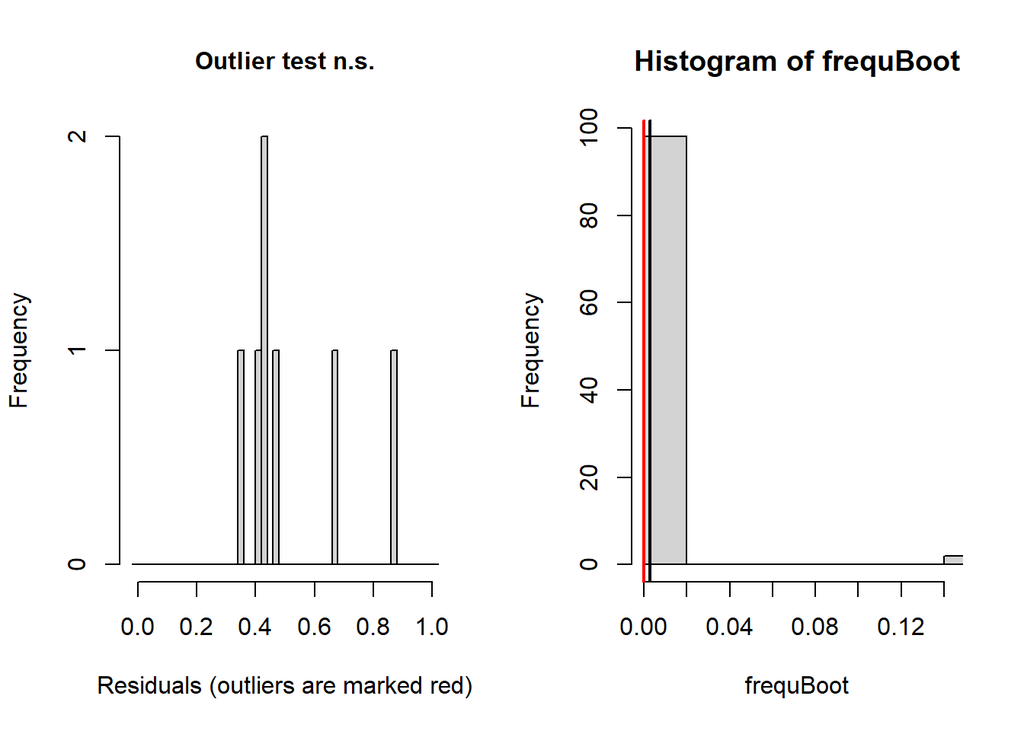

```
##
##  DHARMa bootstrapped outlier test
##
## data:  resids.sub
## outliers at both margin(s) = 0, observations = 1956, p-value = 1
## alternative hypothesis: two.sided
##  percent confidence interval:
##  0 0
## sample estimates:
## outlier frequency (expected: 0.00285714285714286 )
##                                                  0
```

```r
testOutliers(resids.sub, type = "bootstrap") #sign , outliars
```

#Second best model - **Habitat**

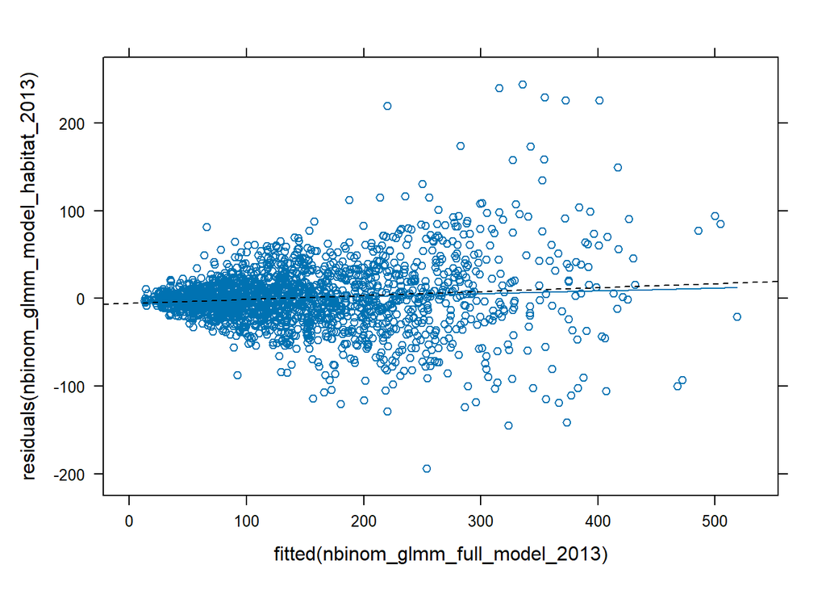

```r
# Check for residual pattern within groups and difference between groups
xyplot(residuals(nbinom_glmm_model_habitat_2013) ~ fitted(nbinom_glmm_full_model_2013),
       panel=function(x, y){
         panel.xyplot(x, y)
         panel.loess(x, y, span = 3)
         panel.lmline(x, y, lty = 2)  # Least squares broken line
       }
)
```

There is some high variation in the residuals - this probably creating the outliars and dispersion roblems inmymodels. lets try to reduce the outliars by removing some marginals locations.

Validation of second Best model - Year * Habitat

```
## DHARMa:testOutliers with type = binomial may have inflated Type I error rates for integer-valued distributions. To get a more exact result, it is recommended to re-run testOutliers with type = 'bootstrap'. See ?testOutliers for details
```

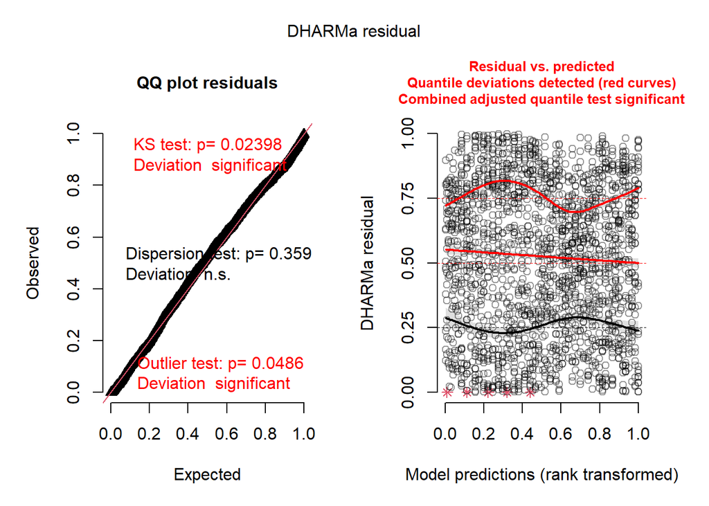

```r
simulationOutput <- simulateResiduals(nbinom_glmm_model_habitat_2013, n = 2000, plot = TRUE,quantreg = T)
```

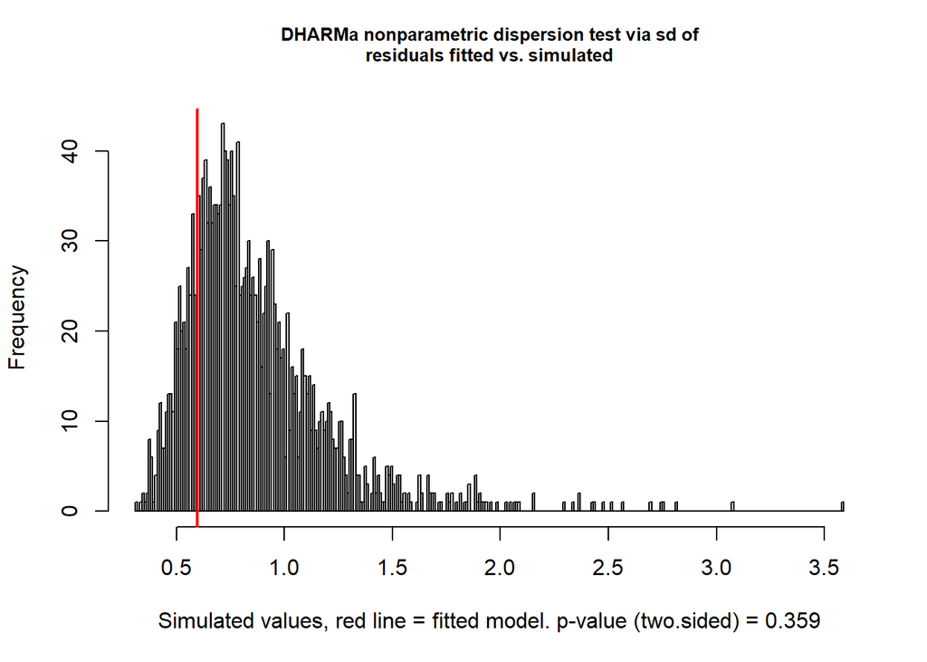

```
##
##  DHARMa nonparametric dispersion test via sd of residuals fitted vs.
##  simulated
##
## data:  simulationOutput
## dispersion = 0.69845, p-value = 0.359
## alternative hypothesis: two.sided
```

```r
testDispersion(simulationOutput) #dispersion fine
```

```
## Unable to calculate quantile regression for quantile 0.25. Possibly to few (unique) data points / predictions. Will be ommited in plots and significance calculations.
```

```
## Unable to calculate quantile regression for quantile 0.5. Possibly to few (unique) data points / predictions. Will be ommited in plots and significance calculations.
```

```
## Unable to calculate quantile regression for quantile 0.75. Possibly to few (unique) data points / predictions. Will be ommited in plots and significance calculations.
```

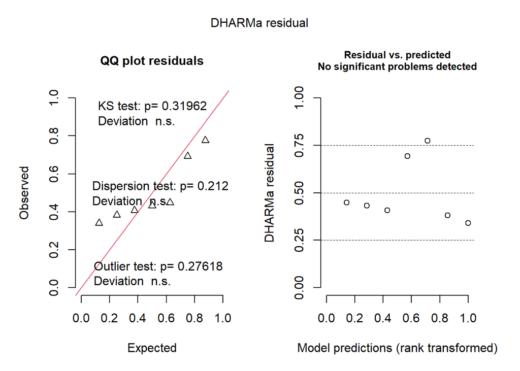

```r
resids.hab <- recalculateResiduals(simulationOutput, group = Total.octo_no_2012$Habitat)
plot(resids.hab) # suggest dispersion problem in the model
```

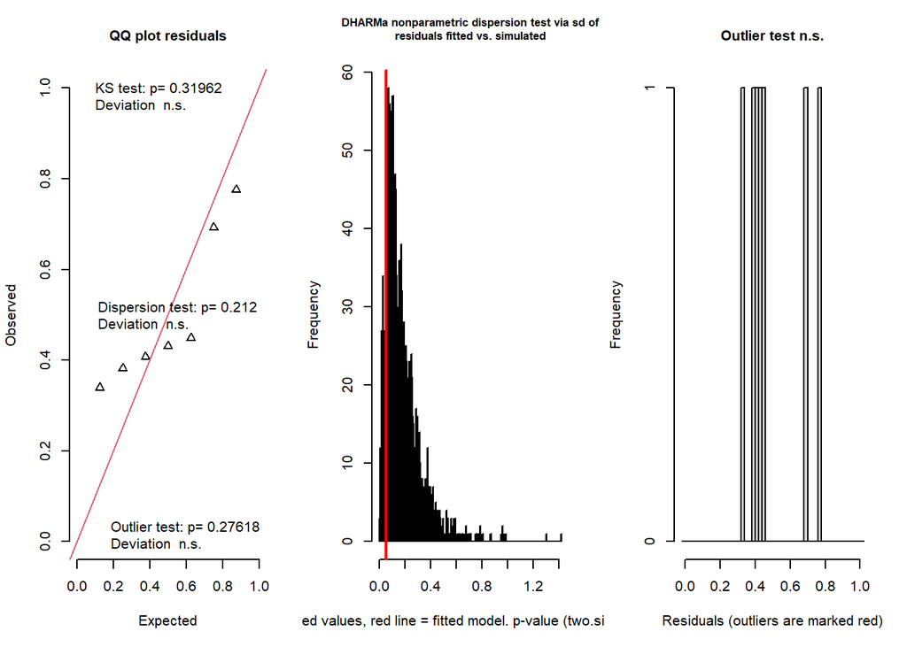

```
## $uniformity
##
##  Exact one-sample Kolmogorov-Smirnov test
##
## data:  simulationOutput$scaledResiduals
## D = 0.3395, p-value = 0.3196
## alternative hypothesis: two-sided
##
##
## $dispersion
##
##  DHARMa nonparametric dispersion test via sd of residuals fitted vs.
##  simulated
##
## data:  simulationOutput
## dispersion = 0.3006, p-value = 0.212
## alternative hypothesis: two.sided
##
##
## $outliers
##
##  DHARMa outlier test based on exact binomial test with approximate
##  expectations
##
## data:  simulationOutput
## outliers at both margin(s) = 0, observations = 1956, p-value = 0.2762
## alternative hypothesis: true probability of success is not equal to 0.0009995002
## 95 percent confidence interval:
##  0.000000000 0.001884153
## sample estimates:
## frequency of outliers (expected: 0.000999500249875062 )
##                                                       0
```

```
## $uniformity
##
##  Exact one-sample Kolmogorov-Smirnov test
##
## data:  simulationOutput$scaledResiduals
## D = 0.3395, p-value = 0.3196
## alternative hypothesis: two-sided
##
##
## $dispersion
##
##  DHARMa nonparametric dispersion test via sd of residuals fitted vs.
##  simulated
##
## data:  simulationOutput
## dispersion = 0.3006, p-value = 0.212
## alternative hypothesis: two.sided
##
##
## $outliers
##
##  DHARMa outlier test based on exact binomial test with approximate
##  expectations
##
## data:  simulationOutput
## outliers at both margin(s) = 0, observations = 1956, p-value = 0.2762
## alternative hypothesis: true probability of success is not equal to 0.0009995002
## 95 percent confidence interval:
##  0.000000000 0.001884153
## sample estimates:
## frequency of outliers (expected: 0.000999500249875062 )
##                                                       0
```

```r
testResiduals(resids.hab) #residuals uniform, dispersion significant and problematic, no outliers b
```

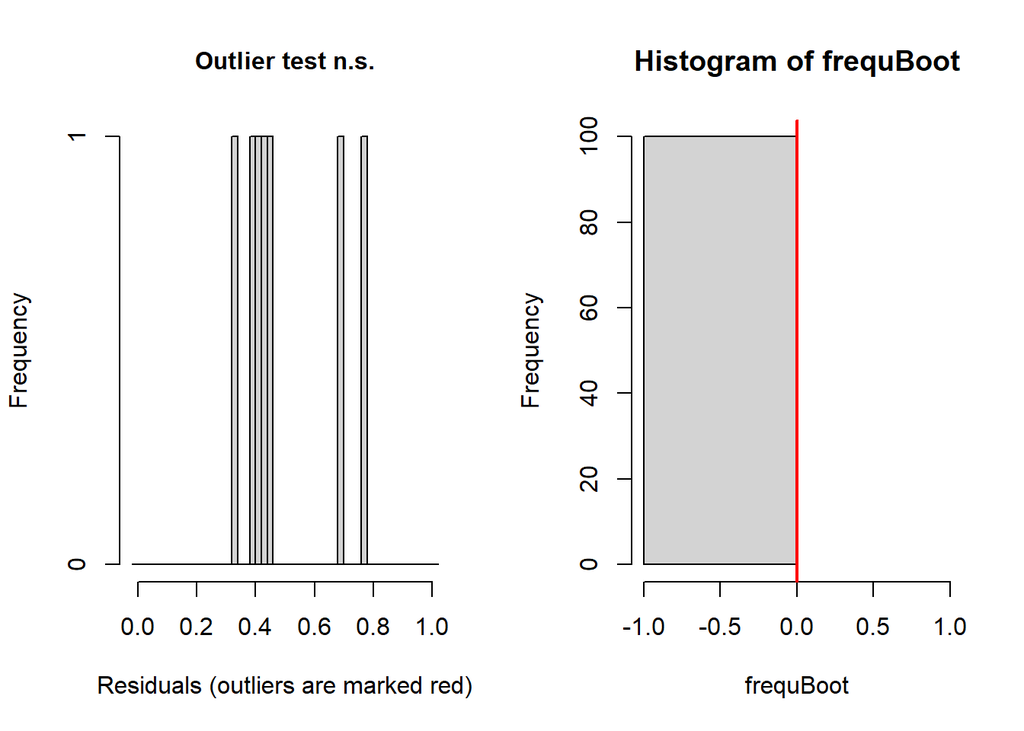

```
##
##  DHARMa bootstrapped outlier test
##
## data:  resids.hab
## outliers at both margin(s) = 0, observations = 1956, p-value = 1
## alternative hypothesis: two.sided
##  percent confidence interval:
##  0 0
## sample estimates:
## outlier frequency (expected: 0 )
##                                0
```

```r
testOutliers(resids.hab, type = "bootstrap") #sign , outliars
```

#Old stuff from here # dont knit

NBINOM1

The difference between using family = nbinom1 and family = nbinom2 is in the parameterization of the negative binomial distribution.  In nbinom1, the variance of the distribution is equal to µ(1 + α), where µ is the mean and α is the estimated dispersion parameter.  This parameterization assumes that the variance increases with the mean.  In nbinom2, the variance of the distribution is µ(1 + µ/θ), where θ is the estimated dispersion parameter.  This parameterization assumes that the variance decreases with the mean.  The choice between the two parameterizations depends on the specific characteristics of the data and the assumptions that best fit the relationship between the mean and variance. Nbinom1 - running models with nbinom2 dist.

#**List of models:** nbinom_glmm_full_model_2013 = glmmTMB(counts ~ Year * Subregion +Depth+Habitat+(1|SiteID/StationID), family = nbinom2, data = Total.octo_no_2012)

nbinom_glmm_model_depthgroup_interaction_2013 <- glmmTMB(counts ~ Year * Depth+ (1|SiteID/StationID), family = nbinom2, data = Total.octo_no_2012)

nbinom_glmm_model_depthgroup_2013 <- glmmTMB(counts ~ Year * Depth_group + (1|SiteID/StationID), family = nbinom2, data = Total.octo_no_2012)

nbinom_glmm_model_depth_2013 <- glmmTMB(counts ~ Year + Depth + (1|SiteID/StationID), family = nbinom2, data = Total.octo_no_2012)

nbinom_glmm_model_Subregion_2013 <- glmmTMB(density ~ Year * Subregion+(1|SiteID/StationID), family = nbinom2, data = Total.octo_no_2012)

nbinom_glmm_model_Subregion2_2013 <- glmmTMB(counts ~ Year + Subregion+(1|SiteID/StationID), family = nbinom2, data = Total.octo_no_2012) # nbinom_glmm_model_Subregion2 <- update(nbinom_glmm_model_Subregion2, control = glmmTMBControl(optCtrl=list(iter.max=1e3,eval.max=1e3)))

nbinom_glmm_model_Subregion3_2013 <- glmmTMB(counts ~ Year * Subregion+Depth + (1|SiteID/StationID), family = nbinom2, data = Total.octo_no_2012)

nbionom_glmm_model_ProjectRegion_2013 <- glmmTMB(counts ~ Year * ProjectRegion+(1|SiteID/StationID), family = nbinom2, data = Total.octo_no_2012)

nbinom_glmm_model_ProjectRegion2_2013 <- glmmTMB(counts ~ Year + ProjectRegion+(1|SiteID/StationID), family = nbinom2, data = Total.octo_no_2012)

nbinom_glmm_model_ProjectRegion3_2013 <- glmmTMB(counts ~ Year * ProjectRegion+Depth+(1|SiteID/StationID), family = nbinom2, data = Total.octo_no_2012)

nbinom_glmm_model_ProjectRegion4_2013 <- glmmTMB(counts ~ Year * ProjectRegion+Habitat+(1|SiteID/StationID), family = nbinom2, data = Total.octo_no_2012)

nbinom_glmm_model_Year_2013 <- glmmTMB(counts ~ as.numeric(Year) + (1|SiteID/StationID), family = nbinom2, data = Total.octo_no_2012)

nbinom_glmm_model_habitat_2013 <- glmmTMB(counts ~ Year * Habitat+(1|SiteID/StationID), family = nbinom2, data = Total.octo_no_2012)

nbinom_glmm_model_habitat2_2013 <- glmmTMB(counts ~ Year + Habitat+(1|SiteID/StationID), family = nbinom2, data = Total.octo_no_2012)

nbinom_glmm_model_habitat3_2013 <- glmmTMB(counts ~ Year + Habitat+Subregion+(1|SiteID/StationID), family = nbinom2, data = Total.octo_no_2012)